# Yelp Rating Prediction Based on Text Review Sentiment Analysis

March 29, 2018

## Improvements

- Larger dataset 10k -> 100k
- Normalized dataset so that there is no intrinsic bias towards higher stars
- More efficient preprocessing and cleaning
- More models!
  - Linear SVM
  - Linerar SVC
  - Logistic Regression
  - Multinomial Naive Bayes
  - Neural Network Classifier
  - Random Forest Classifier

## Word Clouds

I was able to run 'text_process' twice

First to generate the tokens and then to pick the common tokens contained in each list.

['place', 'food', 'good', 'service', 'time', 'get', 'one', 'like', 'back', 'go', 'would']

All these words were in the top 2% of both sentiment word lists

## Word Clouds

Negative

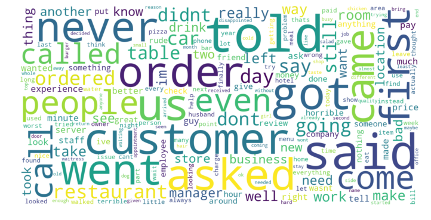

Positive

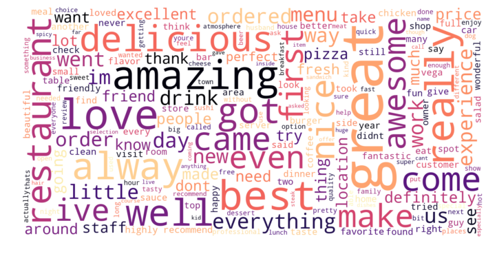

## Linear SVM

- Linear SVM

  ```
  svm.SVC(kernel='linear')
  ```

  - 1 - 5 stars
  - Training time: 213.766s; Prediction time: 65.602s
  - Accuracy Score: 0.5362659088100827
  - 1 & 5 stars
  - Training time: 8.311s; Prediction time: 2.951s
  - Accuracy Score: 0.9484090206981773

## Linear SVM

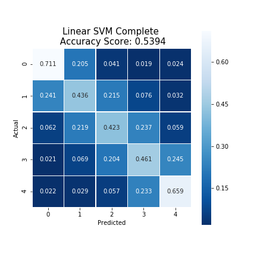

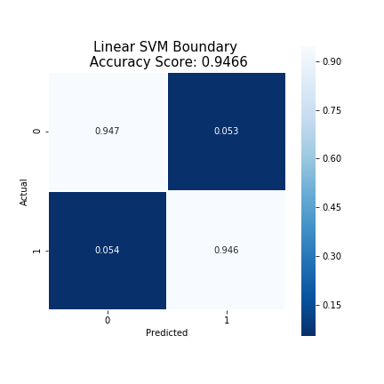

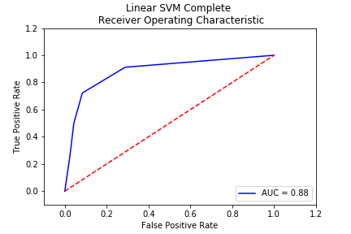

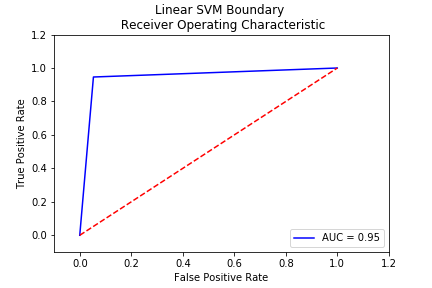

## Linear SVC

- Linear SVC

  ```
  svm.LinearSVC()
  ```

  - 1 - 5 stars
  - Training time: 32.729s; Prediction time: 0.031s
  - Accuracy Score: 0.5357716545162486
  - 1 & 5 stars
  - Training time: 0.964s; Prediction time: 0.002s
  - Accuracy Score: 0.9471733086190918

## Linear SVC

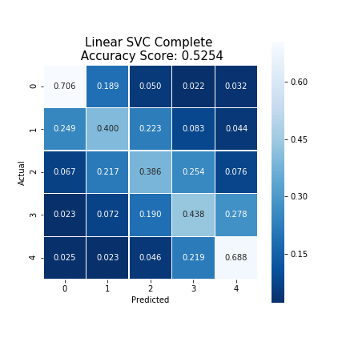

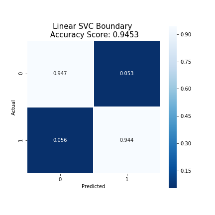

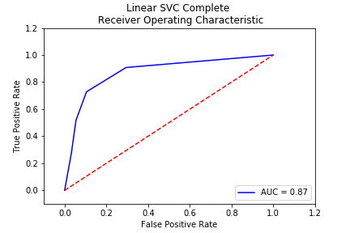

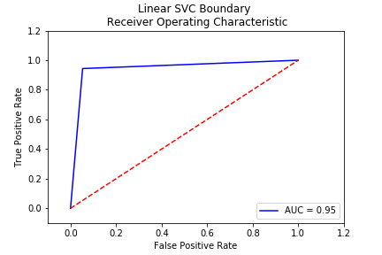

## Logistic Regression

- Logistic Regression

  ```
  LogisticRegression()
  ```

  - 1 - 5 stars
  - Training time: 30.216s; Prediction time: 0.032s
  - Accuracy Score: 0.5487458297293958
  - 1 & 5 stars
  - Training time: 0.962s; Prediction time: 0.002s
  - Accuracy Score: 0.9493358047574915

## Logistic Regression

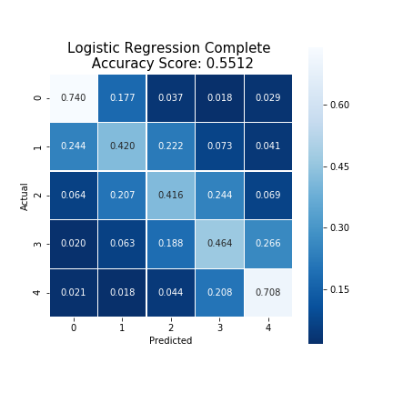

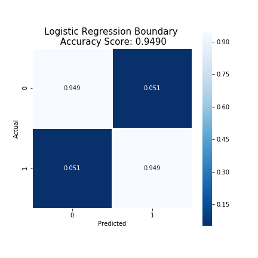

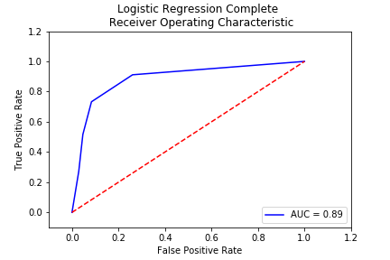

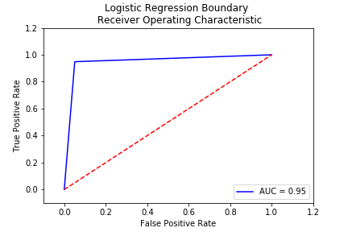

## Multinomial Naive Bayes

```
MultinomialNB()
```

- Multinomial Naive Bayes
  - 1 - 5 stars
  - Training time: 0.242s; Prediction time: 0.050s
  - Accuracy Score: 0.5014209810947733
  - 1 & 5 stars
  - Training time: 0.039s; Prediction time: 0.009s
  - Accuracy Score: 0.9280197713932654

## Multinomial Naive Bayes

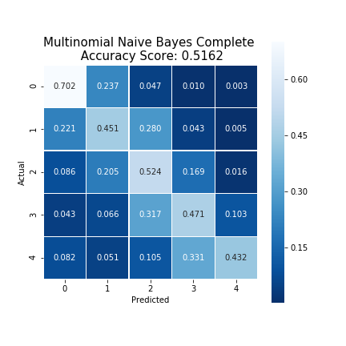

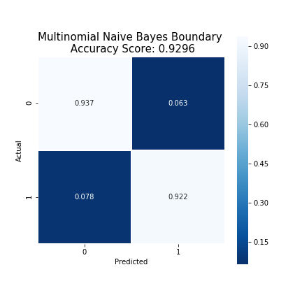

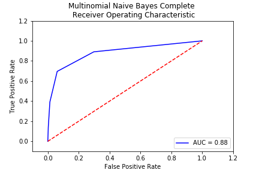

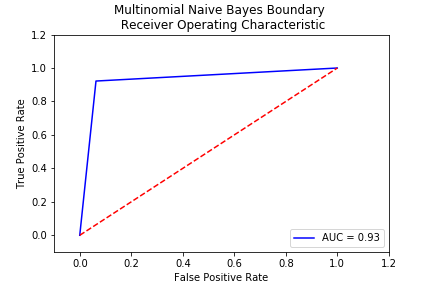

## Neural Network Classifier

```
num_classes = 6
max_words = X_complete_train.shape[1]
batch_size = 32
epochs = 2

classifier_nn_complete = Sequential()
classifier_nn_complete.add(Dense(32, input_shape=(max_words,)))
classifier_nn_complete.add(Activation('relu'))
classifier_nn_complete.add(Dropout(0.5))
classifier_nn_complete.add(Dense(num_classes))
classifier_nn_complete.add(Activation('softmax'))

classifier_nn_complete.compile(loss='sparse_categorical_crossentropy',
                               optimizer='adam',
                               metrics=['accuracy'])
```

## Neural Network Classifier

- Neural Network Classifier
  - 1 - 5 stars
  - Training time: 648.949s; Prediction time: 53.627s
  - Accuracy Score: 0.5759298159344654
  - 1 & 5 stars
  - Training time: 110.639s; Prediction time: 7.984s
  - Accuracy Score: 0.955205437133148

## Neural Network Classifier

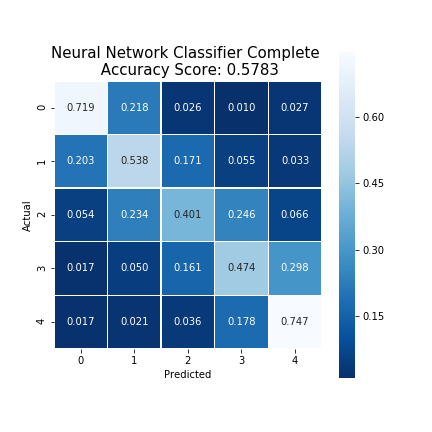

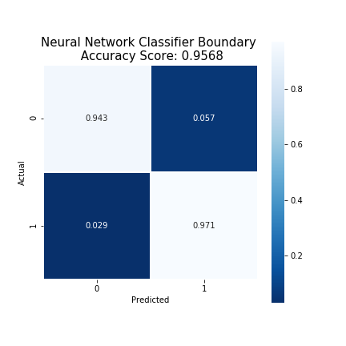

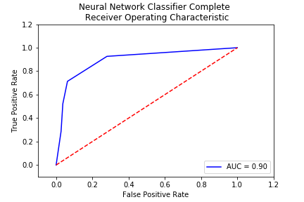

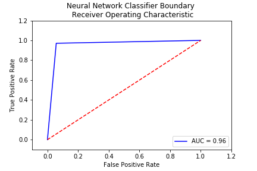

## Random Forest Classifier

```
RandomForestClassifier()
```

## Random Forest Classifier

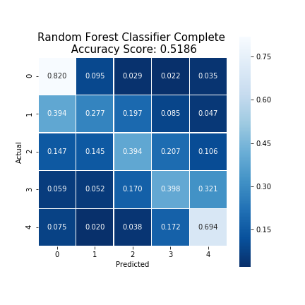

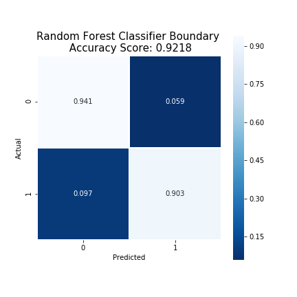

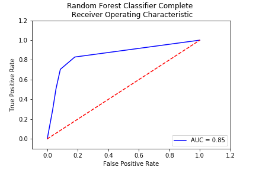

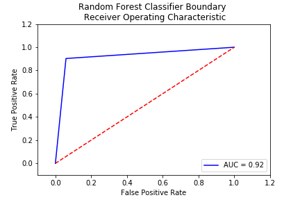

## Training and Prediction Time Compilation

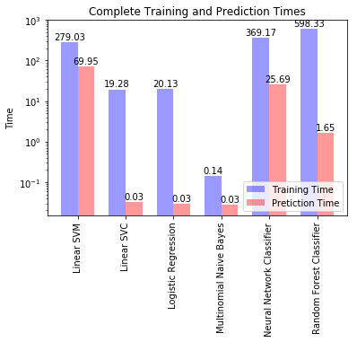

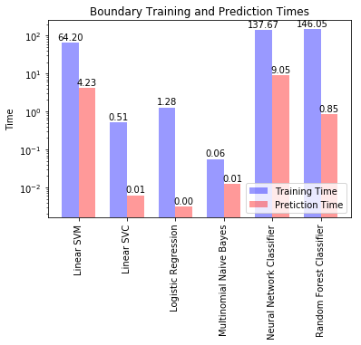

## ROC Compilation

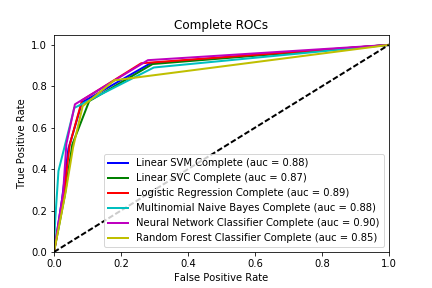

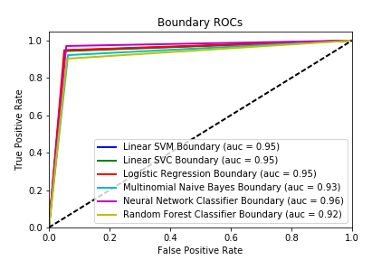

## Up Next

- Set up a function that takes a single prediction confidence and returns a value 1 - 5
  - e.g. Prediction 1 star with a confidence of 0.5 -> 3 star
- This only needs done for the boundary case